# Using wearable-sensor data to predict how well a weight lifting exercise was performed

## Synopsis

The aim of this study was to predict how well a weight lifting exercise, specifically the Unilateral Dumbbell Biceps Curl, was carried out. After initial data cleaning, a random forest model was built using caret and its performance on new data estimated from out-of-bag error rate and validated on data held back from training.

## Introduction

The response, *classe*, is a categorical variable with five levels; A, B, C, D, and E, denoting exactly according to specification (A), throwing the elbows to the front (B), lifting the dumbbell only halfway (C), lowering the dumbbell only halfway (D), and throwing the hips to the front (E). Thus class A is the correct, prescribed execution of the exercise, and the other four classes are common mistakes. The data, and the original study, comes from Velloso et al. [Velloso, E.; Bulling, A.; Gellersen, H.; Ugulino, W.; Fuks, H. Qualitative Activity Recognition of Weight Lifting Exercises. Proceedings of 4th International Conference in Cooperation with SIGCHI (Augmented Human ’13) . Stuttgart, Germany: ACM SIGCHI, 2013] available [here](http://groupware.les.inf.puc-rio.br/har).

## Analysis

```r
require(caret)
require(randomForest)
set.seed(2015)
```

```r
data.training <- read.csv("pml-training.csv")
print(dim(data.training))
```

```
## [1] 19622   160
```

The training data set comprises 19622 observations of 160 variables, so is a substantial size, and importantly contains many variables with no value (NA), both factors have implications for building predictive models.

```r
table(apply(data.training, 2, function(x) sum(is.na(x))))
```

```
##
##     0 19216
##    93    67
```

so 93 of the 160 columns have zero NAs, but 67 have 19216 NAs. Looking at it another way,

```r
table(apply(data.training, 1, function(x) sum(is.na(x))))
```

```
##
##     0    67
##   406 19216
```

the NAs are distributed over the same number of columns in each observation with missing values, implying a pattern. This is summarized by:

```r
addmargins(table(apply(data.training, 1, function(x) sum(is.na(x))), data.training$classe))
```

```
##
##           A     B     C     D     E   Sum
##   0     109    79    70    69    79   406
##   67   5471  3718  3352  3147  3528 19216
##   Sum  5580  3797  3422  3216  3607 19622
```

So a row either has zero NAs or 67, and the NAs occur in 19216 observations out of 19622, spread quite evenly across the classes.

The data columns include indexes, and usernames etc. which should not be included in a predictive model (in this context) because we wish to make predictions based on data received from sensors.

The NAs are seen to occur in the same columns each time, and these appear to be associated with the calculation of summary statistics:

```r
na.cols <- apply(data.training, 2, function(x) sum(is.na(x))) > 0
#Variables with missing values have names that start:
table(unlist(
        lapply(
            strsplit(
                names(data.training[, na.cols]), "_"
                    ), function(x) x[1]
              )
            )
     )
```

```
##
## amplitude       avg       max       min    stddev       var
##         9        12         9         9        12        16
```

As it would seem that the missing values arise from some summary statistics not being calculated for some 98% of the observations, spread very evenly over all classes. Our first approach, therefore, is to delete these columns.

```r
#remove first columns that are only index, username, timestamp etc.
data.training <- data.training[, 8:160]
na.cols <- na.cols[8:160]
keep.colnames <- names(data.training[, !na.cols])
data.training <- data.training[, keep.colnames]
#data.training now comprises only columns containing no NAs
```

Plotting pairs of covariates,

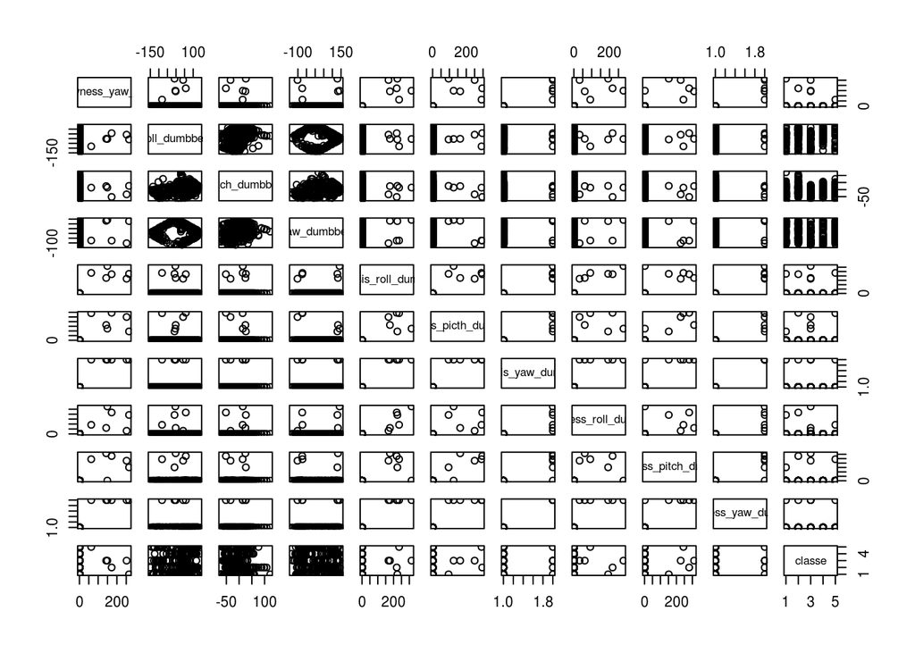

```r
ncols <- ncol(data.training) #response column
pairs(data.training[seq(1, 19622, 50), c(41:50, ncols)]) #for example
```

suggests there are variables that have little variability, specifically a large population clusters around one value, with only a few having a noticeably different value. These covariates (with near zero variance) can be removed thus:

```r
near.stationary.inds <- nearZeroVar(data.training)
#Variable names being dropped:
print(names(data.training)[near.stationary.inds])
```

```
##  [1] "kurtosis_roll_belt"      "kurtosis_picth_belt"
##  [3] "kurtosis_yaw_belt"       "skewness_roll_belt"
##  [5] "skewness_roll_belt.1"    "skewness_yaw_belt"
##  [7] "max_yaw_belt"            "min_yaw_belt"
##  [9] "amplitude_yaw_belt"      "kurtosis_roll_arm"
## [11] "kurtosis_picth_arm"      "kurtosis_yaw_arm"
## [13] "skewness_roll_arm"       "skewness_pitch_arm"
## [15] "skewness_yaw_arm"        "kurtosis_roll_dumbbell"
## [17] "kurtosis_picth_dumbbell" "kurtosis_yaw_dumbbell"
## [19] "skewness_roll_dumbbell"  "skewness_pitch_dumbbell"
## [21] "skewness_yaw_dumbbell"   "max_yaw_dumbbell"
## [23] "min_yaw_dumbbell"        "amplitude_yaw_dumbbell"
## [25] "kurtosis_roll_forearm"   "kurtosis_picth_forearm"
## [27] "kurtosis_yaw_forearm"    "skewness_roll_forearm"
## [29] "skewness_pitch_forearm"  "skewness_yaw_forearm"
## [31] "max_yaw_forearm"         "min_yaw_forearm"
## [33] "amplitude_yaw_forearm"
```

```r
data.training <- data.training[, -near.stationary.inds]
#don't worry, classe (response) is still in here
```

```r
#variable names remaining:
names(data.training)
```

```
##  [1] "roll_belt"            "pitch_belt"           "yaw_belt"
##  [4] "total_accel_belt"     "gyros_belt_x"         "gyros_belt_y"
##  [7] "gyros_belt_z"         "accel_belt_x"         "accel_belt_y"
## [10] "accel_belt_z"         "magnet_belt_x"        "magnet_belt_y"
## [13] "magnet_belt_z"        "roll_arm"             "pitch_arm"
## [16] "yaw_arm"              "total_accel_arm"      "gyros_arm_x"
## [19] "gyros_arm_y"          "gyros_arm_z"          "accel_arm_x"
## [22] "accel_arm_y"          "accel_arm_z"          "magnet_arm_x"
## [25] "magnet_arm_y"         "magnet_arm_z"         "roll_dumbbell"
## [28] "pitch_dumbbell"       "yaw_dumbbell"         "total_accel_dumbbell"
## [31] "gyros_dumbbell_x"     "gyros_dumbbell_y"     "gyros_dumbbell_z"
## [34] "accel_dumbbell_x"     "accel_dumbbell_y"     "accel_dumbbell_z"
## [37] "magnet_dumbbell_x"    "magnet_dumbbell_y"    "magnet_dumbbell_z"
## [40] "roll_forearm"         "pitch_forearm"        "yaw_forearm"
## [43] "total_accel_forearm"  "gyros_forearm_x"      "gyros_forearm_y"
## [46] "gyros_forearm_z"      "accel_forearm_x"      "accel_forearm_y"
## [49] "accel_forearm_z"      "magnet_forearm_x"     "magnet_forearm_y"
## [52] "magnet_forearm_z"     "classe"
```

## Predictive model

Having now removed columns associated with housekeeping, columns containing 98% NAs, and columns of near zero variance, we then partition the training data into a set used for model building and a set left aside that is then only used to assess/confirm model performance.

```r
inTrain <- createDataPartition(y=data.training$classe, p=0.6, list=FALSE)

training <- data.training[inTrain, ]
testing <- data.training[-inTrain, ]

require(doMC)
registerDoMC(cores = 7)

modelCacheFile <- "modfit.rds"
if (file.exists(modelCacheFile)) {
    modfit <- readRDS(modelCacheFile)
} else {
    system.time(modfit <- train(classe ~ ., method="rf", data=training, verbose=FALSE))
}
```

Having reduced the number of columns, and using 60% of the training data for model building, the memory requirements are now such that we could easily parallelize this step over 7 cores. This consumed around 80% of 8 GB RAM system memory and took some 15 minutes on an i7.

Model parameters are:

```r
print(modfit)
```

```
## Random Forest
##
## 11776 samples
##    52 predictors
##     5 classes: 'A', 'B', 'C', 'D', 'E'
##
## No pre-processing
## Resampling: Bootstrapped (25 reps)
##
## Summary of sample sizes: 11776, 11776, 11776, 11776, 11776, 11776, ...
##
## Resampling results across tuning parameters:
##
##   mtry  Accuracy   Kappa      Accuracy SD  Kappa SD
##    2    0.9862376  0.9825854  0.002108999  0.002668706
##   27    0.9867077  0.9831812  0.001659704  0.002097896
##   52    0.9749890  0.9683531  0.005528995  0.007010610
##
## Accuracy was used to select the optimal model using  the largest value.
## The final value used for the model was mtry = 27.
```

A key question is what error rate we might expect from this model when we apply it to out-of-sample data, i.e. data not involved in the model training. For random forests, we can get this estimate from the out-of-bag estimate of error rate for the final model:

```r
print(modfit$finalModel)
```

```
##
## Call:
##  randomForest(x = x, y = y, mtry = param$mtry, verbose = FALSE)
##                Type of random forest: classification
##                      Number of trees: 500
## No. of variables tried at each split: 27
##
##         OOB estimate of  error rate: 0.8%
## Confusion matrix:
##      A    B    C    D    E class.error
## A 3342    3    2    1    0 0.001792115
## B   21 2247   10    1    0 0.014041246
## C    0   11 2038    4    1 0.007789679
## D    0    0   26 1903    1 0.013989637
## E    0    2    3    8 2152 0.006004619
```

The confusion matrix looks good, and the out-of-bag estimate of error rate stands at just 0.8%. Ultimately, we wish to verify our performance estimate on the held back data:

```r
#the 40% of data not previously used
cm <- confusionMatrix(testing$classe, predict(modfit, testing))
print(cm)
```

```
## Confusion Matrix and Statistics
##
##           Reference
## Prediction    A    B    C    D    E
##          A 2222    5    4    0    1
##          B   13 1497    8    0    0
##          C    0    5 1354    9    0
##          D    0    1   12 1273    0
##          E    0    1    4    7 1430
##
## Overall Statistics
##
##                Accuracy : 0.9911
##                  95% CI : (0.9887, 0.993)
##     No Information Rate : 0.2849
##     P-Value [Acc > NIR] : < 2.2e-16
##
##                   Kappa : 0.9887
##  Mcnemar's Test P-Value : NA
##
## Statistics by Class:
##
##                      Class: A Class: B Class: C Class: D Class: E
## Sensitivity            0.9942   0.9920   0.9797   0.9876   0.9993
## Specificity            0.9982   0.9967   0.9978   0.9980   0.9981
## Pos Pred Value         0.9955   0.9862   0.9898   0.9899   0.9917
## Neg Pred Value         0.9977   0.9981   0.9957   0.9976   0.9998
## Prevalence             0.2849   0.1923   0.1761   0.1643   0.1824
## Detection Rate         0.2832   0.1908   0.1726   0.1622   0.1823
## Detection Prevalence   0.2845   0.1935   0.1744   0.1639   0.1838
## Balanced Accuracy      0.9962   0.9944   0.9888   0.9928   0.9987
```

```r
#sum of off diagonals divided by total = error rate
er <- (sum(cm$table)-sum(diag(cm$table))) / sum(cm$table)
```

The overall accuracy of 99.1% is impressive, and the class-specific accuracies (A: 99.6%, B: 99.4%, C: 98.9%, D: 99.3%, and E: 99.9%) compare favourably with those obtained by Velloso et al. (A: 97.6%, B: 97.3%, C: 98.2%, D: 98.1%, and E: 99.1%, with weighted average of 98.2%). The error rate of 0.9 on the testing set agrees with the out-of-bag estimate from the random forest model.

## Summary

A work flow was demonstrated from reading in data, cleaning the data and performing sensible, justifiable, feature selection, through to model building and obtaining an estimate of out of sample error rate subsequently confirmed on an independent data set (not used in model building). Prediction performance was very good, comparing favourably to that of the original authors.